# Modeling and prediction for movies

*Entry date: 29-10-2019*

## Setup

### Load packages

```r
library(ggplot2)
library(dplyr)
library(statsr)
```

### Load data

Make sure the path of my working directory is properly set.

```r
load("movies.Rdata")
```

## Part 1: Data

- **Generalizability:** The dataset comprises of 651 *randomly sampled* movies produced and released before the year 2016. This suggests that the data (movies) are *generalizable* to a wider base of all movies. However, they may only be generalized to movies produced and released before 2016, and only to the extent of which movies are selected to be included on IMDb and Rotten Tomatoes in the first place. In other words, if there are restrictions at the very start on certain types of movie inclusion, such as movies limited to specific languages, then the generalizability of these 651 randomly sampled movies will be undermined.
- **Causality:** Since the collected data are observational in nature and not yielded by random assignment, *causality may not be inferred* from the results.

## Part 2: Research question

> Do movie ratings on IMDb differ according to their genre, runtime and critics rating on Rotten Tomatoes?

I am interested to learn if there are certain movie genres that render more popularity amongst people, and whether or not movie runtimes also influence a movie’s popularity. However, it is to note that because I am using movie rating on IMDb as proxy to a movie’s popularity, I am assuming that a movie’s popularity is reflected by its ratings given on IMDb, as opposed to say, the number of times the movie was watched. This assumption may be inaccurate.

I am also keen to learn if there is a relationship between movie ratings on IMDb and critics ratings on Rotten Tomatoes - both of which are online databases of aggregated information on many movies. If the relationship between *movie ratings on IMDb* and *critics ratings of movies on Rotten Tomatoes* are inversely proportional, then it provides an additional validation of a movie’s popularity.

## Part 3: Exploratory data analysis

The variables that I will be using are:

- **Response variable:** imdb_rating (movie rating on IMDb reflecting a movie’s popularity)
- **Explanatory variables/ predictors:** genre (movie genre: action, comedy, documentary etc), runtime (runtime of movie in minutes), critics_rating (critics rating grouped on Rotten Tomatoes: Certified Fresh, Fresh, Rotten)

I will now create a new dataframe and only selecting my interested variables.

```r
#select interested variables and remove one row containing NA
movies1<-movies%>%select(c("title","imdb_rating","genre","runtime","critics_rating"))%>%filter(!is.na(runtime))

#verify data type of each selected variable
str(movies1)
```

```
## tibble [650 × 5] (S3: tbl_df/tbl/data.frame)
##  $ title         : chr [1:650] "Filly Brown" "The Dish" "Waiting for Guffman" "The Age of Innocence" ...
##  $ imdb_rating   : num [1:650] 5.5 7.3 7.6 7.2 5.1 7.8 7.2 5.5 7.5 6.6 ...
##  $ genre         : Factor w/ 11 levels "Action & Adventure",..: 6 6 4 6 7 5 6 6 5 6 ...
##  $ runtime       : num [1:650] 80 101 84 139 90 78 142 93 88 119 ...
##  $ critics_rating: Factor w/ 3 levels "Certified Fresh",..: 3 1 1 1 3 2 3 3 2 1 ...
```

For the EDA task, I will be producing tables of summary statistics and simple graphs to help with visualising three relationships:

1. Movie genre and IMDb rating
2. Movie runtime and IMDb rating
3. Critics rating on Rotten Tomatoes and IMDb rating

Distribution of all movie ratings on IMDb

```r
#summary statistics 1
summary(movies1$imdb_rating)
```

```
##    Min. 1st Qu.  Median    Mean 3rd Qu.    Max.
##   1.900   5.900   6.600   6.492   7.300   9.000
```

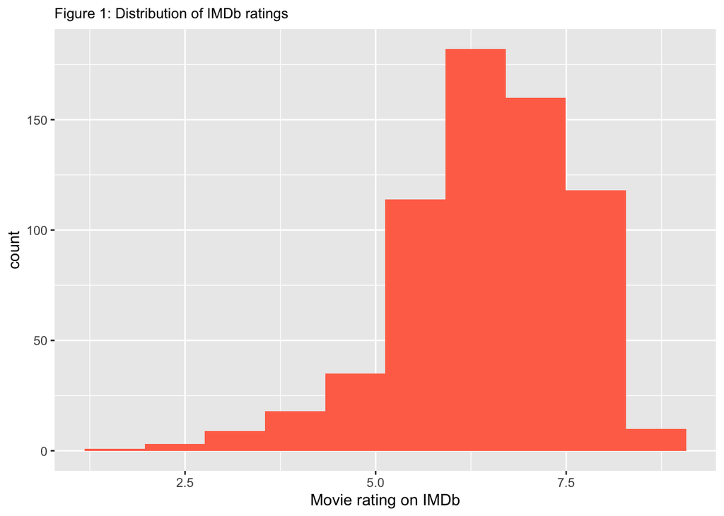

```r
#graph 1: histogram showing distribution of imdb ratings
ggplot(movies1,aes(x=imdb_rating))+geom_histogram(bins=10,fill="coral1")+labs(title="Figure 1: Distribution of IMDb ratings")+theme(plot.title=element_text(size=10))+xlab("Movie rating on IMDb")
```

*Interpretation*

The distribution of movie ratings on IMDb is slightly left skewed, suggesting that only a minor proportion of movies are rated poorly (<5/10). The mean and median values are 6.5 and 6.6 respectively - relatively close to one another.

Relationship between movie genre and IMDb rating

```r
#summary statistics 2
movies1%>%group_by(genre)%>%summarise(mean_imdb_rating=mean(imdb_rating))%>%arrange(desc(mean_imdb_rating))
```

```
## # A tibble: 11 x 2
##    genre                     mean_imdb_rating
##    <fct>                                <dbl>
##  1 Documentary                           7.65
##  2 Musical & Performing Arts             7.3
##  3 Drama                                 6.67
##  4 Other                                 6.63
##  5 Art House & International             6.61
##  6 Mystery & Suspense                    6.48
##  7 Action & Adventure                    5.97
##  8 Animation                             5.9
##  9 Horror                                5.76
## 10 Science Fiction & Fantasy             5.76
## 11 Comedy                                5.74
```

[figure not shown]

```r
#graph 2: boxplot showing relationship between IMDb rating and movie genre
ggplot(movies1,aes(x=genre,y=imdb_rating))+geom_boxplot()+labs(title="Figure 2: Relationship between movie genre and IMDb rating")+theme(plot.title=element_text(size=10))+xlab("Movie genre")+ylab("IMDb rating")+scale_x_discrete(labels=c("Action","Animation","Art hse","Comedy","Docu","Drama","Horror","Musical","Mystery","Other","SciFi"))
```

*Interpretation*

Documentaries receive the highest average IMDb rating (7.65), followed with Musical and Performing Arts (7.30) and then Drama (6.67). The genre receiving the lowest average IMDb rating is Comedy at 5.74. Horror and Science Fiction films receive the same average ratings at 5.76.

From Figure 2, I can see that the IQR is widest for SciFi movies, meaning that the spread of IMDb ratings amongst the middle 50% of people is largest for this movie genre - there is a wide variation of views in regards to SciFi movies. In a similar vein, the IQR is leanest for Documentaries. As such, I may speculate (based on the visualizations alone) that in addition to the observation that Documentaries are the most popular/ highly ranked movie genre on IMDb, there is less variation in its ratings too - most people are relatively unanimous in favoring Documentaries in comparison to other genres.

It is also to be noted that most of the individual boxplots overlap with each other. This implies that there may not be significant differences in averages between the different movie genres. An inference test may be conducted to validate this statement.

Relationship between movie runtime and IMDb rating

```r
#summary statistics 3
summary(movies1$runtime)
```

```
##    Min. 1st Qu.  Median    Mean 3rd Qu.    Max.
##    39.0    92.0   103.0   105.8   115.8   267.0
```

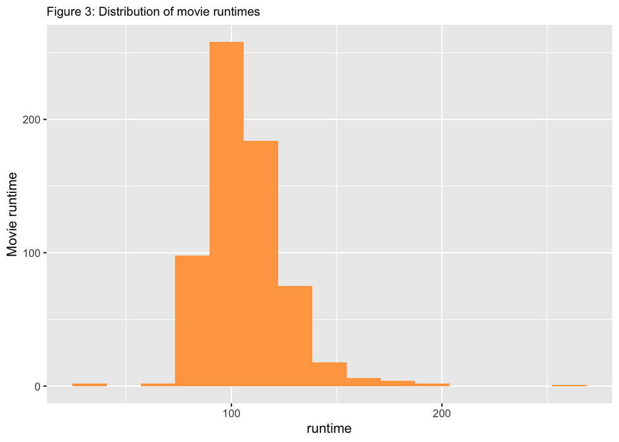

```r
#graph 3: histogram distribution of movie runtimes
ggplot(movies1,aes(x=runtime))+geom_histogram(bins=15,fill="tan1")+labs(title="Figure 3: Distribution of movie runtimes")+ylab("Movie runtime")+theme(plot.title=element_text(size=10))
```

[figure not shown]

```r
#graph 4: scatterplot showing relationship between imdb rating and movie runtime
ggplot(movies1,aes(x=runtime,y=imdb_rating,colour=genre))+geom_jitter()+labs(title="Figure 4: Relationship between movie runtime and IMDb rating")+theme(plot.title=element_text(size=10),legend.title=element_text(size=8),legend.text=element_text(size=5))+xlab("Movie runtime (minutes)")+ylab("IMDb rating")
```

```r
#calculate correlation coefficient of the relationship
movies1%>%summarise(cor(runtime,imdb_rating))
```

```
## # A tibble: 1 x 1
##   `cor(runtime, imdb_rating)`
##                         <dbl>
## 1                       0.268
```

*Interpretation*

From the summary statistics, the average movie runtime for all 650 movies is 105.8 minutes (1.76 hours), with the shortest runtime at 39.0 minutes (0.65 hours) and the longest at 267.0 minutes (4.45 hours). These are the outliers.

Below, I fit a liner regression model on the scatterplot as plotted before. However, whether or not the model can actually be applied to the data depends on meeting the conditions of linearity, normal distribution of residuals, and constant variability of residuals.

[figure not shown]

```r
ggplot(movies1,aes(x=runtime,y=imdb_rating))+geom_jitter()+labs(title="Figure 5: Relationship between movie runtime and IMDb rating, fitted with a linear regression line ")+theme(plot.title=element_text(size=10))+xlab("Movie runtime (minutes)")+ylab("IMDb rating")+stat_smooth(method="lm",se=FALSE)
```

Relationship between Critics rating on Rotten Tomatoes and IMDb rating

```r
#summary statistics 4
movies1%>%group_by(critics_rating)%>%summarise(mean_imdb_rating=mean(imdb_rating),median_imdb_rating=median(imdb_rating))%>%arrange(desc(mean_imdb_rating))
```

```
## # A tibble: 3 x 3
##   critics_rating  mean_imdb_rating median_imdb_rating
##   <fct>                      <dbl>              <dbl>
## 1 Certified Fresh             7.40                7.4
## 2 Fresh                       6.95                7
## 3 Rotten                      5.78                5.9
```

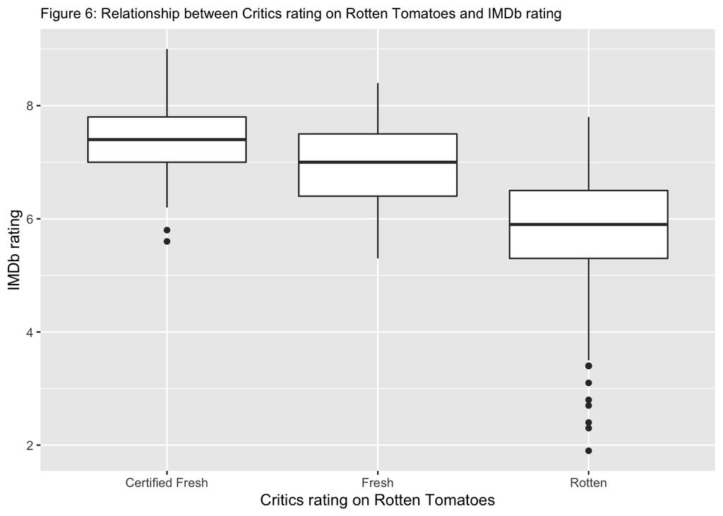

```r
#graph 6: boxplot showing relationship between IMDb rating and critics rating on RT
ggplot(movies1,aes(x=critics_rating,y=imdb_rating))+geom_boxplot()+labs(title="Figure 6: Relationship between Critics rating on Rotten Tomatoes and IMDb rating")+theme(plot.title=element_text(size=10))+xlab("Critics rating on Rotten Tomatoes")+ylab("IMDb rating")
```

*Interpretation*

The mean and median values for movie ratings on IMDb are fairly similar for all three groups of critics rating on Rotten Tomatoes, implying that the distributions of IMDb ratings across each group are roughly symmetrical.

True enough, the table of summary statistics and Figure 6 show that IMDb ratings for movies voted as ‘Rotten’ are the lowest whereas IMDb ratings for movies voted as ‘Certified Fresh’ are the highest. However, similar to my interpretation of the previously plotted boxplots, it seems like there are overlaps in the IQR of IMDb ratings between ‘Certified Fresh’ and ‘Fresh’ groups. An inference test comparing the mean or median values (parameter of interest) will be useful to determine if the observed differences in IMDb ratings between groups are statistically different.

## Part 4: Modeling

Now I’d like build a multiple linear regression model consisting of three of my explanatory variables of interest.

```r
#fit model
lm1<-lm(imdb_rating~genre+runtime+critics_rating,data=movies1)

summary(lm1)
```

```
##
## Call:
## lm(formula = imdb_rating ~ genre + runtime + critics_rating,
##     data = movies1)
##
## Residuals:
##     Min      1Q  Median      3Q     Max
## -3.4412 -0.3977  0.0277  0.4903  2.1319
##
## Coefficients:
##                                 Estimate Std. Error t value Pr(>|t|)
## (Intercept)                     5.984231   0.216085  27.694  < 2e-16 ***
## genreAnimation                 -0.162765   0.274485  -0.593  0.55340
## genreArt House & International  0.400932   0.226200   1.772  0.07680 .
## genreComedy                    -0.166951   0.126072  -1.324  0.18590
## genreDocumentary                1.035839   0.150762   6.871 1.53e-11 ***
## genreDrama                      0.273390   0.107261   2.549  0.01104 *
## genreHorror                    -0.117119   0.186859  -0.627  0.53103
## genreMusical & Performing Arts  0.688531   0.243068   2.833  0.00476 **
## genreMystery & Suspense         0.218496   0.139268   1.569  0.11717
## genreOther                      0.138616   0.215766   0.642  0.52082
## genreScience Fiction & Fantasy -0.501079   0.273105  -1.835  0.06701 .
## runtime                         0.010031   0.001661   6.038 2.66e-09 ***
## critics_ratingFresh            -0.423913   0.085466  -4.960 9.06e-07 ***
## critics_ratingRotten           -1.348771   0.083206 -16.210  < 2e-16 ***
## ---
## Signif. codes:  0 '***' 0.001 '**' 0.01 '*' 0.05 '.' 0.1 ' ' 1
##
## Residual standard error: 0.7658 on 636 degrees of freedom
## Multiple R-squared:  0.5117, Adjusted R-squared:  0.5017
## F-statistic: 51.27 on 13 and 636 DF,  p-value: < 2.2e-16
```

*Interpretation of regression output/ t-test*

Looking at the estimates on the regression output, the linear model can be written as follows:

> *movie rating on IMDb* = 5.98 - 0.16 *genre: animation* + 0.4 *genre: art house* - 0.17 *genre: comedy* + 1.04 *genre: documentary* + 0.27 *genre: drama* - 0.12 *genre: horror* + 0.69 *genre: musicals* + 0.22 *genre: mystery* + 0.14 *genre: other* - 0.5 *genre: scifi* + 0.01 *runtime* - 0.42 *critics rating: fresh* - 1.35 *critics rating: rotten*

Intercept coefficient: The intercept is 5.98, meaning when all of the variables are valued at 0, the movie rating on IMDb will be 5.98 - this is not meaningful in any practical way.

Estimate coefficients: A one unit increase in the respective explanatory variable yields an increase or decrease of movie rating on IMDb by its corresponding estimate - with all other variables held constant. For example, a movie with a critics rating of Rotten on Rotten Tomatoes will have a decrease in its movine rating on IMDb by 1.34.

Individual P-value coefficients: There are 6 explanatory variables that are significant (p<0.05). This means that slope coefficients for these 6 variables are statistically diferrent from 0 (I reject the null hypothesis claiming that these slope coefficients are 0 aka there is no relationship between the respective explanatory and response variable). In other words, these six variables contribute to the model, while the rest do not.

Multiple R-squared: 51.17% of the total variability of the response variable is explained by the model. Seems like a rather weak fitting model?

F-statistic and overall p-value: The overall p-value for the F-statistic is statistically significant, implying that the model is useful - the model accounts for the variability of the response variable more than it would be expected by chance.

```r
#produce anova table
anova(lm1)
```

```
## Analysis of Variance Table
##
## Response: imdb_rating
##                 Df Sum Sq Mean Sq F value    Pr(>F)
## genre           10 173.47  17.347  29.580 < 2.2e-16 ***
## runtime          1  37.90  37.902  64.631 4.414e-15 ***
## critics_rating   2 179.48  89.738 153.022 < 2.2e-16 ***
## Residuals      636 372.98   0.586
## ---
## Signif. codes:  0 '***' 0.001 '**' 0.01 '*' 0.05 '.' 0.1 ' ' 1
```

*Interpretation of ANOVA output*

Critics rating on Rotten Tomatoes explains the highest proportion of variablity of movie rating on IMDb, followed with movie genre and lastly movie runtime.

**Model selection: Backward elimination using the p-value and adjusted R-squared approaches**

Next, I’d like to refine the current model that I have, and evaluate which predictor variables are most useful to the model. Since I will be using the backward elimination strategy, I will start with the full model and drop one predictor at a time until a parsimonious model is obtained.

p-value approach

Key: Repeat the dropping of predictor variables with the highest p-value and refitting of smaller models until all left in the model are significant.

1. Full model

```r
summary(lm1)
```

```
##
## Call:
## lm(formula = imdb_rating ~ genre + runtime + critics_rating,
##     data = movies1)
##
## Residuals:
##     Min      1Q  Median      3Q     Max
## -3.4412 -0.3977  0.0277  0.4903  2.1319
##
## Coefficients:
##                                 Estimate Std. Error t value Pr(>|t|)
## (Intercept)                     5.984231   0.216085  27.694  < 2e-16 ***
## genreAnimation                 -0.162765   0.274485  -0.593  0.55340
## genreArt House & International  0.400932   0.226200   1.772  0.07680 .
## genreComedy                    -0.166951   0.126072  -1.324  0.18590
## genreDocumentary                1.035839   0.150762   6.871 1.53e-11 ***
## genreDrama                      0.273390   0.107261   2.549  0.01104 *
## genreHorror                    -0.117119   0.186859  -0.627  0.53103
## genreMusical & Performing Arts  0.688531   0.243068   2.833  0.00476 **
## genreMystery & Suspense         0.218496   0.139268   1.569  0.11717
## genreOther                      0.138616   0.215766   0.642  0.52082
## genreScience Fiction & Fantasy -0.501079   0.273105  -1.835  0.06701 .
## runtime                         0.010031   0.001661   6.038 2.66e-09 ***
## critics_ratingFresh            -0.423913   0.085466  -4.960 9.06e-07 ***
## critics_ratingRotten           -1.348771   0.083206 -16.210  < 2e-16 ***
## ---
## Signif. codes:  0 '***' 0.001 '**' 0.01 '*' 0.05 '.' 0.1 ' ' 1
##
## Residual standard error: 0.7658 on 636 degrees of freedom
## Multiple R-squared:  0.5117, Adjusted R-squared:  0.5017
## F-statistic: 51.27 on 13 and 636 DF,  p-value: < 2.2e-16
```

I cannot drop any more variables, as all of my predictor variables have at least one level in which it is significant (p-value<0.05)

Adjusted R-squared approach

Key: Repeat the dropping of predictor variables until the adjusted R-squared cannot be increased further.

1. Full model

Adjusted R-squared: 0.5017

2. Drop variable movie genre

Adjusted R-squared: 0.436

3. Drop variable movie runtime

Adjusted R-squared: 0.474

4. Drop variable critics rating on Rotten Tomatoes

Adjusted R-squared: 0.2643

*Interpretation*

Since all of the adjusted R-squared values upon the initial step of dropping each predictor variable are lower than the original full models’ (0.5017), I retain the full model as the best model (at least in comparison).

**Diagnostic plots**

Four assumptions have to be met for the fitting of the above multiple linear regression model to be valid:

- Nearly normal residuals around 0
- Linear relationships between numerical predictor variables and the response variable
- Constant variability of residuals
- Independence of residuals

Nearly normal residuals

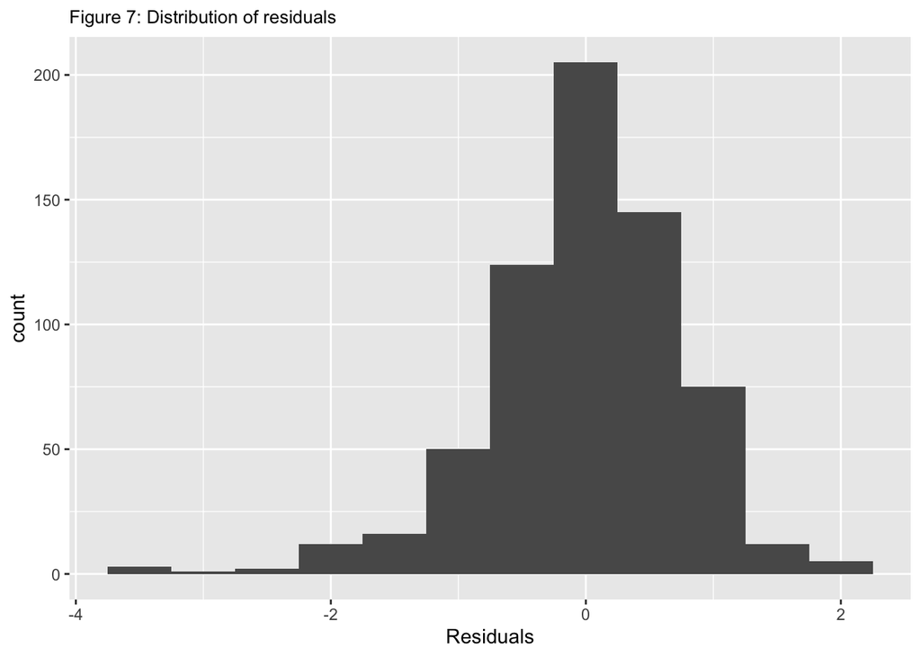

```r
#plot histogram of residuals
ggplot(lm1,aes(x=.resid))+geom_histogram(binwidth=0.5)+labs(title="Figure 7: Distribution of residuals")+theme(plot.title=element_text(size=10))+xlab("Residuals")
```

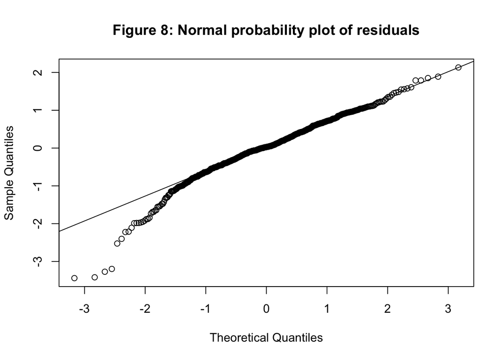

```r
#plot normal probability plot of residuals
qqnorm(lm1$residuals,main="Figure 8: Normal probability plot of residuals")
qqline(lm1$residuals)
```

*Interpretation*

Figure 7 show a slightly left skewed distribution of residuals. However, Figure 8 does not show any major irregularities or deviations of the residuals except for at the tail ends. This condition seems to be fairy satisfied.

Linear relationship between movie runtime (numerical predictor variable) and movie rating on IMDb

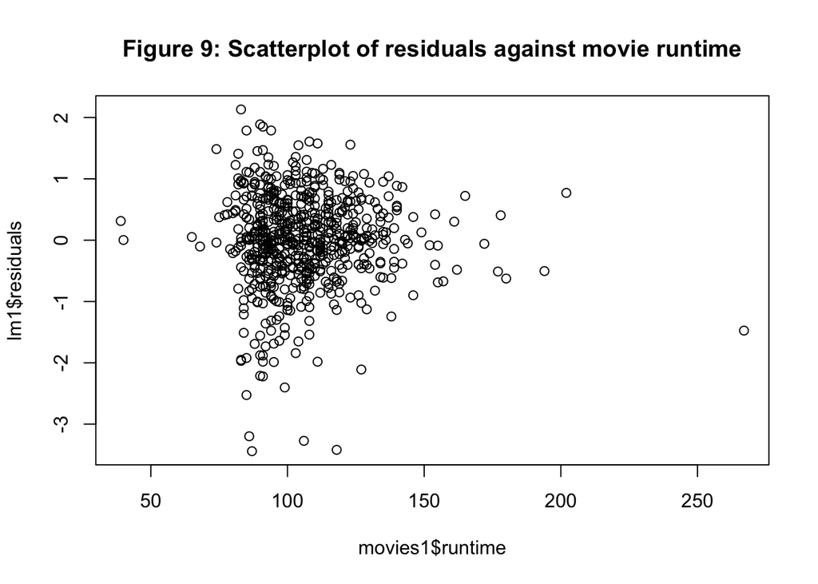

```
## integer(0)
```

```r
#plot scatterplot of residuals against the numerical predictor variable
plot(lm1$residuals~movies1$runtime)+title(main="Figure 9: Scatterplot of residuals against movie runtime")
```

*Interpretation*

Figure 9 does not seem to show a randomly scattered plot of residuals around the y-intercept 0. There seems to be an underlying structure of a fan-shaped pattern. This condition does not seem to be satisfied.

Constant variability of residuals

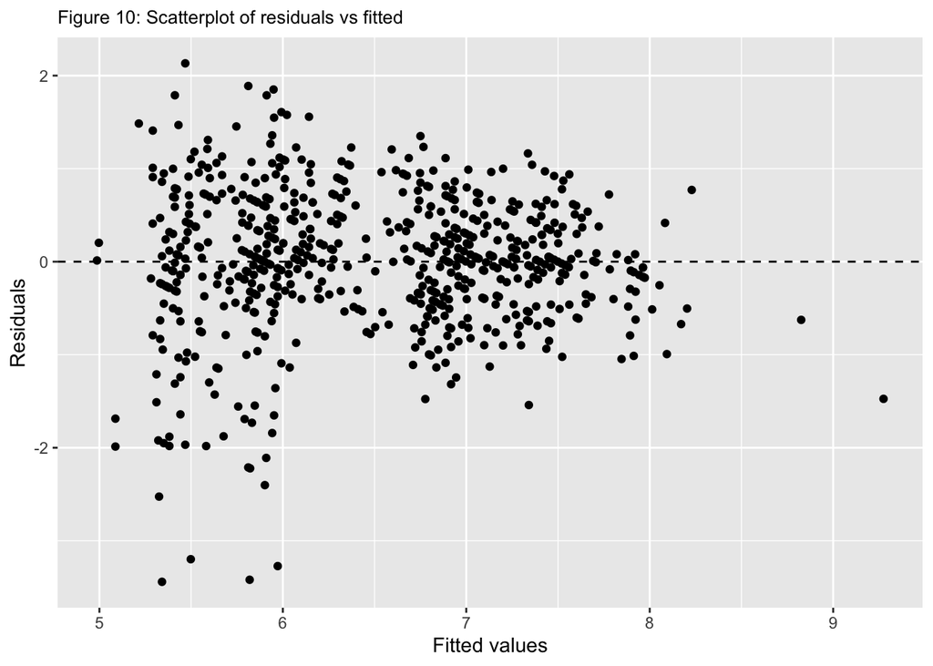

```r
#plot scatterplot of residuals against fitted values
ggplot(lm1,aes(x=.fitted,y=.resid))+geom_point()+labs(title="Figure 10: Scatterplot of residuals vs fitted")+theme(plot.title=element_text(size=10))+xlab("Fitted values")+ylab("Residuals")+geom_hline(yintercept=0,linetype="dashed")
```

*Interpretation*

The distribution of residuals on Figure 10 seems to show a fan-shaped pattern - variability of residuals does not seem to be constant across the fitted values.

Independence of residuals

There is no reason to believe that the movies are dependent upon one another.

## Part 5: Prediction

I will now use my model to predict the rating of a movie, which is not part of the original sample, on IMDb. The movie is It: Chapter Two released in 2019.

```r
#create new df for movie it
IT<-data.frame(genre="Horror",runtime=169,critics_rating="Rotten")

#predict
predict(lm1,IT,interval="prediction",level=0.95)
```

```
##        fit      lwr      upr
## 1 6.213631 4.656207 7.771055
```

## Part 6: Conclusion

Going back to my research question of ‘Do movie ratings on IMDb differ according to the movie’s genre, runtime and critics rating on Rotten Tomatoes?’ - the EDA does not allow me to answer the research question. If anything, it only lets me speculate whether or not movie ratings on IMDb are dependent on a movie’s genre, runtime and critics rating on Rotten Tomatoes - one explanatory variable at a time. To truly deduce if these explanatory variables do make a difference on IMDb ratings, inference tests (hypothesis testing) would have to be conducted - again, one explanatory variable at a time.

As such, a multiple regression analysis serves to describe the relationship between *a set* of explanatory variables and the response variable. From my multiple regression model, I understand that the genre, runtime and critic’s rating of a movie on Rotten Tomatoes are all significant predictors of a movie’s rating on IMDb. However, movie ratings of only Documentaries, Dramas, or Musicals can be significantly predicted.

Furthermore, it also looks like my model is not a strong model, as the multiple R-squared is only of a mediocre (0.5) value.

*Self-reflection: I struggled a little with this exercise, although it took me much quicker to finish this course on Linear Regression and Modeling. My struggle came with the many coefficients produced by the regression and ANOVA outputs and how to interpret these estimates in the context of the data. I need to study more on this topic*